# Praca Domowa 5

Karol Pysiak

November 20, 2018

# Wstęp

# Statystyki z komentarzem

### Wykres 1.

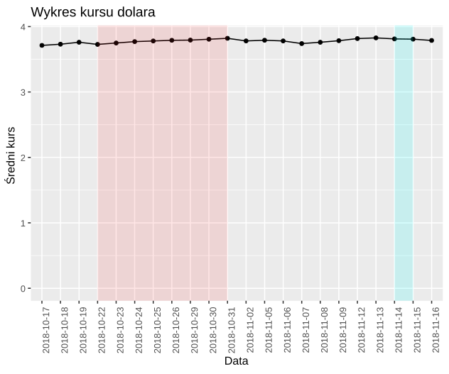

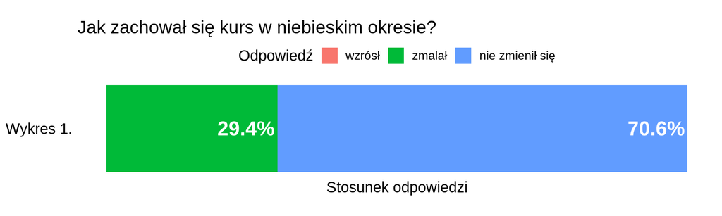

#### Odp:

`zmalał`

#### Komentarz:

W tej statystyce spodziwałem się bardzo dużej rozbieżności zdań ankietowanych, ponieważ wykres w tym miejscu jest praktycznie płaski. Myślałem, że intuicyjnie ankietowani będą zaznaczać losowo wzrósł lub zmalał, jednakże większość wybrała odpowiedź `nie zmienił się`, a pojawiły się także odpowiedzi poprawne, przy czym nie było w ogóle odpowiedzi `wzrósł`.

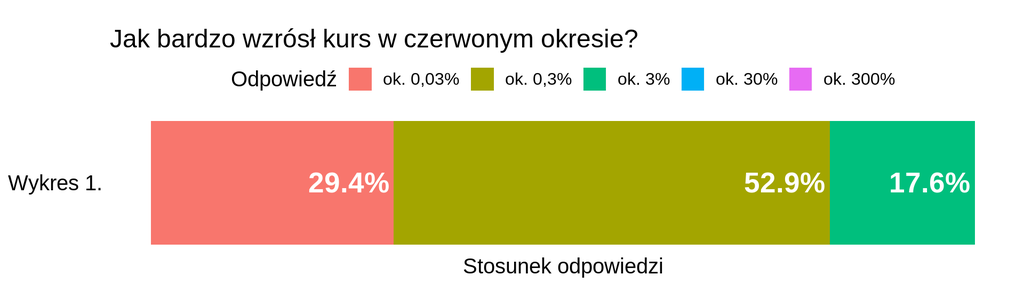

#### Odp:

`3%`

#### Komentarz:

Wyniki tego pytania całkowicie minęły się z moimi oczekiwaniami. Spodziewałem się, że takie zaprezentowanie danych będzie sprzyjało poprawnej odpowiedzi, jednakże jedynie $17,6\%$ osób trafiło z odpowiedzią. Wypłaszczenie wykresu wywołało tendencję do zaniżania wzrostu kursu w ocenie ankietowanych.

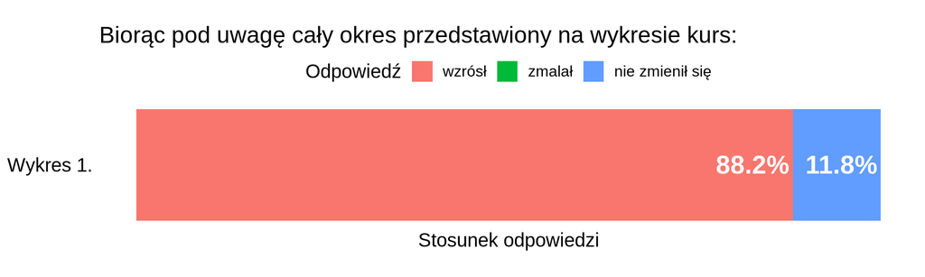

#### Odp:

`wzrósł`

#### Komentarz:

W tym przypadku dla zdecydowanej większości osób nie było problemem określenie ogólnego trendu wykresu i nie ma w tym nic zaskakującego, jednakże spodziewałem się delikatnie wyższej liczby błędnych odpowiedzi.

### Wykres 2.

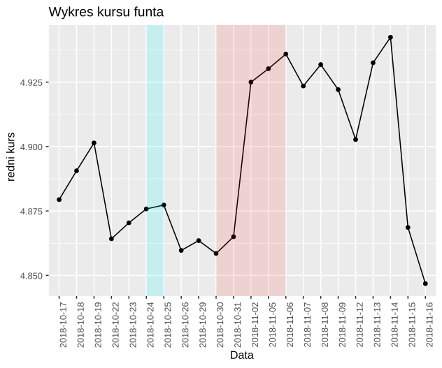

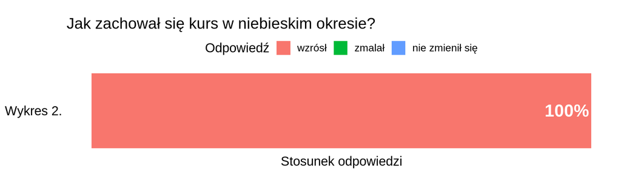

#### Odp:

`wzrósł`

#### Komentarz:

Wykres 2. sprzyja określaniu zachowania się kursu dzięki czemu wszyscy ankietowani odpowiedzieli poprawnie.

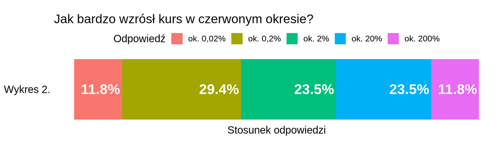

#### Odp:

`2%`

#### Komentarz:

Ankietowani mieli problem z określeniem jak bardzo podniósł się kurs. Odpowiedzi były skrajnie różne, jednakże $23,5\%$ osób wskazało poprawną odpowiedź, co jest zaskakująco dużą wartością, gdyż określenie wartości wzrostu wymagało dużego zaangażownaia w przeanalizowanie wykresu.

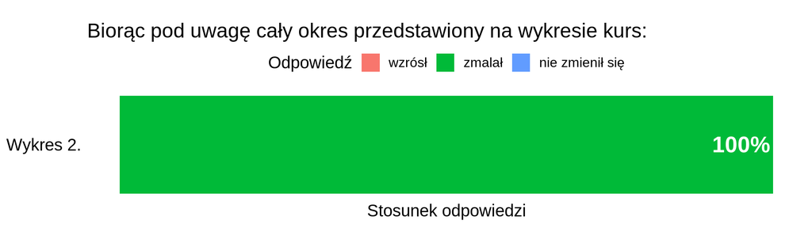

#### Odp:

`zmalał`

#### Komentarz:

Tak samo jak w pierwszym pytaniu określenie zachowania się kursu jest bardzo proste na Wykresie 2.

# Podsumowanie

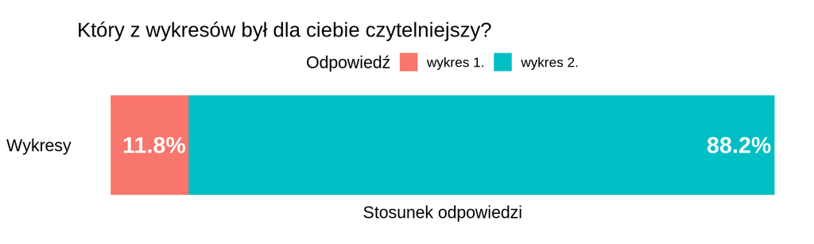

Ten stosunek doskonale podsumowuje całą ankietę. Zdecydowanie lepiej został odebrany Wykres 2., był on dla czytelników zdecydowanie czytelniejszy. Robiąc tą ankietę stawiałem sobie tezę, że oba wykresy mają swoje wady i zalety, oraz że pola ich zastosowania się uzupełniają. Jak widać moja teza została obalona. Szczególnie ważne było dla mnie drugi pytanie, gdzie pytałem o procent wzrostu kursu. Myślałem, że Wykres 1. ułatwi odpowiedź na to pytanie dzięki umieszczeniu początku skali w $0$, jednakże jakość odbioru była jeszcze gorsza od Wykresu 2. Pozostałe dwa pytania była to domena Wykresu 2. i to właśnie chciałem potwierdzić, że tego typu wizualizacja pomaga w określaniu trendów.